# CHROM plot

28 January, 2026

```r
t1 <- Sys.time()
```

## Data input

In order to create a plot of chromosomes we need information on the chromosome names and their lengths. Here we read this information in from a comma delimited files (*.csv). For the purposes of this example, we decided it would be best to have a ‘stand alone’ code example that does not require any inputs. To acomplish this, the following code chunck has been disabled, but has been left as an example.

```r
nucs <- read.csv("../ideograms/EH23b.softmasked_nuccomp.csv")
```

In order to create a stand alone example, that does not require file input, we’ve saved a data structure below so that it can be read into memory. This is similar to what we could have accomplished through file input.

```r
#dput(nucs[ , c("Id", "Length")])
nucs <- structure(list(Id = c("EH23b.chr1", "EH23b.chr5", "EH23b.chr2",
"EH23b.chr3", "EH23b.chr4", "EH23b.chr7", "EH23b.chr8", "EH23b.chr9",
"EH23b.chr6", "EH23b.chrX"), Length = c(63722626L, 78289000L,
80157000L, 83805000L, 81133510L, 64212500L, 55650000L, 65951000L,
80012778L, 84401000L)), class = "data.frame", row.names = c(NA,
-10L))
nucs[1:3, ]
```

```
##           Id   Length
## 1 EH23b.chr1 63722626
## 2 EH23b.chr5 78289000
## 3 EH23b.chr2 80157000
```

Our goal here is to start with a `data.frame` that has at least two columns named ‘Id’ and ‘length’. We will be using `ggplot2` to plot our chromosomes, and ggplot2 uses column names to specify which columns to use. This means the user may have to add these themselves. An example of how this might be accomplished follows.

```r
colnames(nucs)[c(1, 2)] <- c("Id", "Length")
```

The column names ‘Id’ is a ‘word’ name for each chromosome. We also need a numeric chromosome name that specifies the order the chromosomes should appear in the plot. Our chromosome numbers are embedded in the ‘Id’ column. We can make this information available with a little bit of code.

```r
nucs$chrom_num <- sub(".+chr", "", nucs$Id)
nucs$chrom_num[ nucs$chrom_num == "X" ] <- 10
nucs$chrom_num <- as.numeric(nucs$chrom_num)
nucs[1:3, ]
```

```
##           Id   Length chrom_num
## 1 EH23b.chr1 63722626         1
## 2 EH23b.chr5 78289000         5
## 3 EH23b.chr2 80157000         2
```

The goal is to create a column named ‘chrom_num’ which contains the chromosome number. You may not have the chromosome number embeded in your ‘Id’ and may have to retrieve this data elsewhere.

## A Simple Plot

We can now use the data.frame created above to create a simple plot with ggplot2.

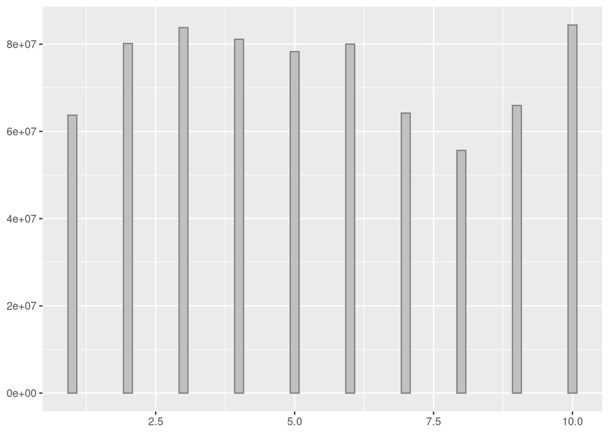

```r
library(ggplot2)
chr_width <- 0.08

p <- ggplot( data = nucs,
             mapping = aes(
               xmin = chrom_num - chr_width,
               xmax = chrom_num + chr_width,
               ymin = 1,
               ymax = Length) )
p <- p + geom_rect( fill = "#C0C0C0", color = "#808080" )
p
```

I refer to this plot as simple because it uses default values for plotting. This allows us to validate that we have successfully plotted the correct information. Once we have a simple plot, we can modify it to make it aesthetically pleasing.

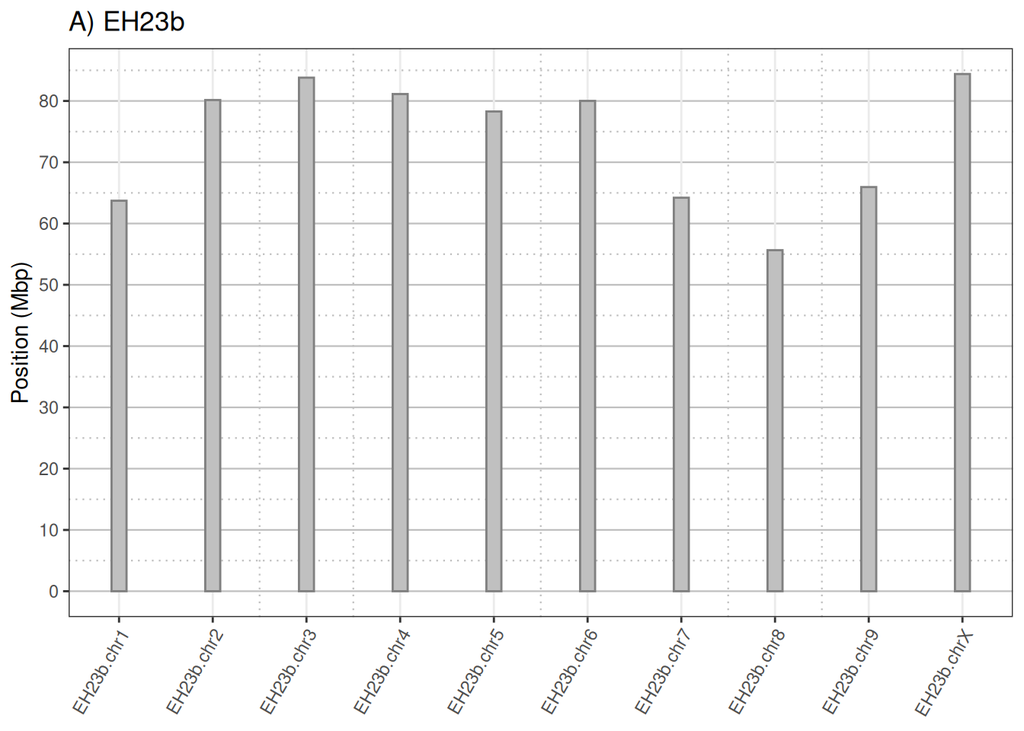

```r
# Theme
p <- p + theme_bw()
p <- p + scale_x_continuous(
  breaks = nucs$chrom_num,
#  limits = c(0.6, 10.4),
  labels = sub("a.chr", ".chr", nucs$Id)
)

p <- p + scale_y_continuous(
  breaks = seq( 0, 120e6, by = 10e6),
  labels = seq( 0, 120, by = 10)
)


p <- p + theme(
    panel.grid.minor.x = element_line(
      linewidth = 0.4, color = "#C0C0C0", linetype = 3 ),
    axis.text.x = element_text(angle = 60, hjust = 1),
    axis.title.x = element_blank(),
    panel.grid.major.y = element_line(
      linewidth = 0.4, color = "#C0C0C0", linetype = 1 ),
    panel.grid.minor.y = element_line(
      linewidth = 0.4, color = "#C0C0C0", linetype = 3 )
  )

p <- p + ylab("Position (Mbp)")
p <- p + ggtitle( "A) EH23b" )

p
```

## Add features

We can now add features to our chromosomes. These features may be genes, or exons, or anything. We’ll need to know the chromosome and start and end positions for each feature. This information may come from a biological feature format file (BED, GFF, GTF, etc.), which presents an issue because they typically do not include header information that can be used as column names. This is an issue because ggplot2 uses column names to select columns of data. This can be added manually by modifying the below example to the specifics of your data.

```r
colnames(nucs)[c(1, 3, 4)] <- c("CHROM", "START", "STOP")
```

For the purposes of our example, we will simulate some feature coordinates.

```r
n_feats <- 10
my_feats <- data.frame(
  chrom = sample(nucs$chrom_num, size = n_feats, replace = TRUE),
  start = rnorm( n = n_feats, mean = 40e6, sd = 1e7)
)
my_feats$end <- my_feats$start + 1e7
my_feats
```

```
##    chrom    start      end
## 1      8 29774230 39774230
## 2      7 44436626 54436626
## 3      8 37202118 47202118
## 4      4 45476694 55476694
## 5      5 48722007 58722007
## 6      4 30902314 40902314
## 7      4 32236916 42236916
## 8     10 41862028 51862028
## 9      4 32882326 42882326
## 10     9 37356703 47356703
```

Our goal here is to have a data.frame that has columns named ‘chrom’, ‘start’, and ‘end’. This information can be used to add rectangular features to the plot.

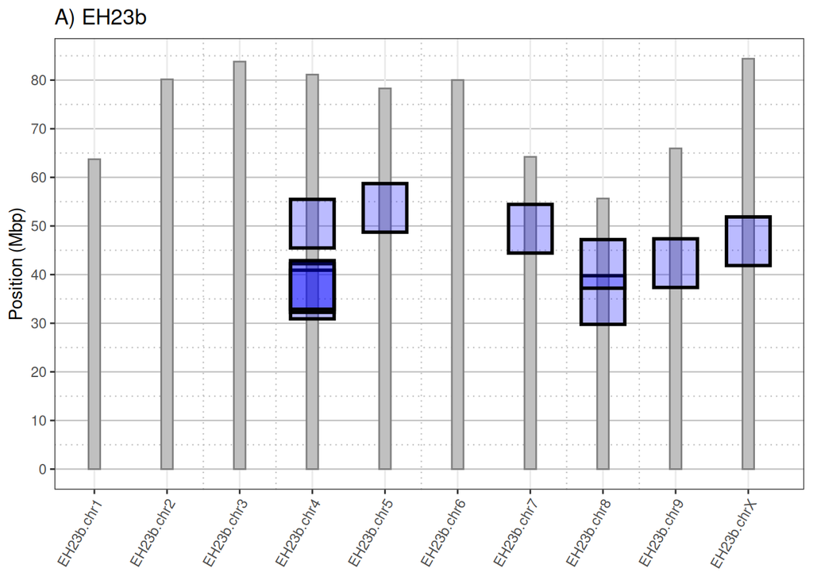

```r
feat_width <- 0.3

p + geom_rect( data = my_feats,
               mapping = aes(
                 xmin = chrom - feat_width,
                 xmax = chrom + feat_width,
                 ymin = start, ymax = end),
               colour = "#000000", fill = "#0000FF44", linewidth = 1
)
```

Here, the features are 10 million base pairs tall (1e7; a one with seven zeros), which is fairly large. This illustrates that rectangles consist of a fill and a border. The border is specified by the linewidth parameter and it’s size is independent of the feature’s height. This may be desirable for small features. The border may be omitted by using a transparent color(“#00000000”) leaving just the fill, which may represent the size of the feature better. However, if the feature is small it may not plot. These paramenters may be adjusted to find a combination that appears pleasing.

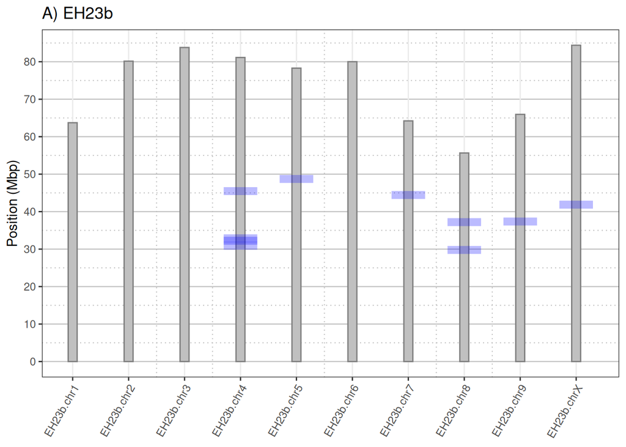

```r
feat_width <- 0.3
my_feats$end <- my_feats$start + 1e2

p <- p + geom_rect( data = my_feats,
               mapping = aes(
                 xmin = chrom - feat_width,
                 xmax = chrom + feat_width,
                 ymin = start, ymax = end),
               colour = "#0000FF44", fill = "#0000FF00", linewidth = 3
)
p
```

## Zoom

Regions of the plot may be specified as follows.

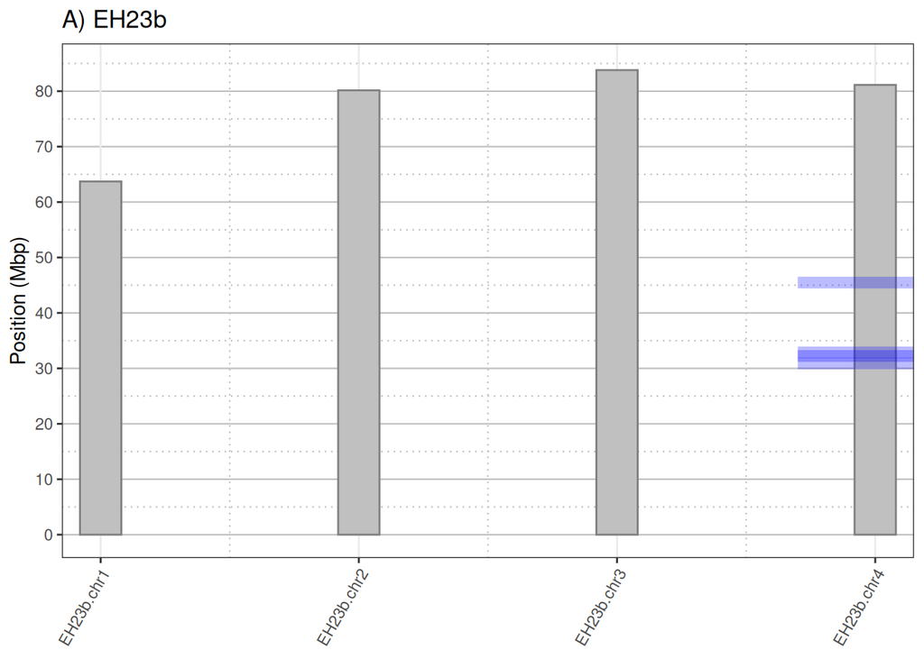

```r
#p + xlim(1.6, 4)
p + coord_cartesian( xlim = c(1, 4) )
```

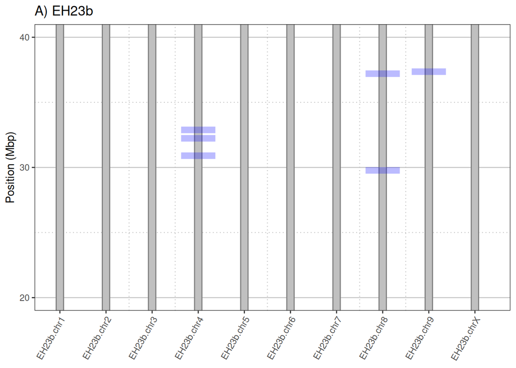

```r
p + coord_cartesian( ylim = c(20e6, 40e6) )
```

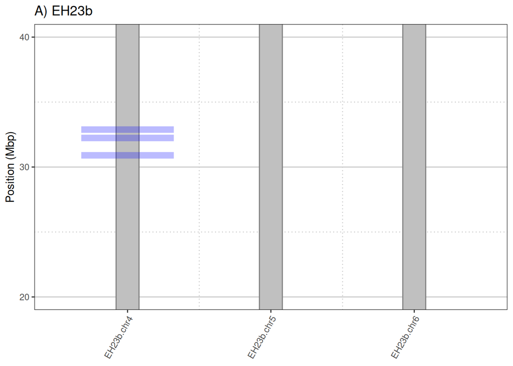

```r
p + coord_cartesian( xlim = c(3.5, 6.5), ylim = c(20e6, 40e6) )
```

## Save graphic

This graphic can be saved in any of the file types supported by R. Below are examples of png (good for electronic media) and tiff (for manuscripts).

```r
ggsave( filename = "my_ideogram.png", plot = p,
        device = "png",
        width = 6.5, height = 6.5,
        units = "in", dpi = 300)
```

```r
ggsave( filename = "my_ideogram.tiff", plot = p,
        device = "tiff",
        width = 6.5, height = 6.5,
        units = "in", dpi = 300, compression = "lzw")
```

```r
t99 <- Sys.time()
t99 - t1
```

```
## Time difference of 3.988394 secs
```